# Stats 506 F20 Final Project

Aravind Mantravadi

12/11/2020

# 1 Introduction

This project answers the question “do people in the US get their macronutrient intake primarily at home or from elsewhere?” Eating outside is often assumed to be unhealthy, while home-cooked meals are supposed to provide a more nutritious and balanced diet. What does this tell us about the macronutrient split based on their source?

To analyze this, I used the NHANES 2017-18 Nutrition Dataset and the 2017-18 Demographics Dataset and gathered the variables that contained survey weights, macronutrient intake and the source of the nutrient. There are 28 different sources of food and I manually classified them into “home-cooked” and “outside”. For more detail about the classification, refer to the **Data and Methods** section.

Finally, I found the mean of each macronutrient along with a 95% confidence interval, split by the source of food. This gave me a way to compare the average macronutrient intake by source.

# 2 Data and Methods

I used the [NHANES 2017-18 Nutrition Dataset](https://wwwn.cdc.gov/nchs/nhanes/search/datapage.aspx?Component=Dietary&CycleBeginYear=2017) and the [NHANES 2017-18 Demographic Dataset](https://wwwn.cdc.gov/nchs/nhanes/Search/DataPage.aspx?Component=Demographics&CycleBeginYear=2017)

For dataset manipulation, I used the **dplyr package** in tidyverse collection of packages. I merged the two datasets and kept only the variables of interest – the survey weights, macronutrients, total food intake and source of food. Then, I manipulated the source of food as mentioned in the Introduction section and then used the functions provided by the **survey package** to find the average of each macronutrient for each source of food. The estimates are given with a 95% confidence interval and they take into account the survey weights.

The results were compared visually using tables and charts, and they consist of a frequency table of the data, a table of means for each macronutrient, and a bar graph showing the food intake from the different sources. The code for this analysis can be found [here](https://github.com/aravind1338/506F20FinalProject).

## 2.1 Categorizing food source

I manually categorized the food sources listed in the variable “DR1FS”. I chose to place codes 1, 10, 11, 12, 18, 19, 20 under “home-cooked” and the rest as “outside”. You can find detailed information about the codes [here](https://wwwn.cdc.gov/Nchs/Nhanes/2017-2018/DR1IFF_J.htm#DR1FS)

# 3 Results

Table 1: Frequency distribution of data by source

| Source | Frequency |
| --- | --- |
| home-cooked | 44895 |
| outside | 22424 |

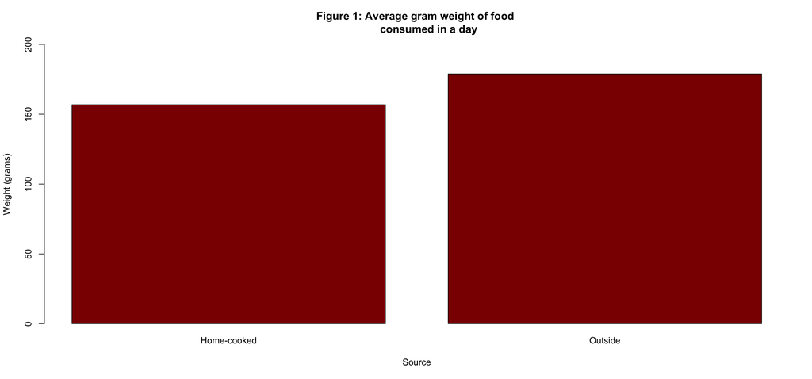

Table 2: Average macronutrient intake by source (grams). Format: estimate (lower, upper)

| Source | Proteins | Carbohydrates | Sugars | Fibers | Fats |
| --- | --- | --- | --- | --- | --- |
| home-cooked | 5.6 ( 4.6, 6.6) | 15.5 (13.7, 17.3) | 6.9 ( 5.9, 7.9) | 1.3 ( 1.1, 1.5) | 5.3 ( 4.6, 6.0) |
| outside | 4.9 ( 4.2, 5.5) | 13.8 (12.2, 15.4) | 5.2 ( 4.4, 5.9) | 0.9 ( 0.7, 1.0) | 5.8 ( 5.0, 6.6) |

The results in the tables and figures above illuminate quite a few things.

1. From Table 2, we can see that people in the US **primarily** get their macronutrient intake from home-cooked meals rather than outside sources. But, one interesting exception is the split of fat consumed between home-cooked and outside sources.
2. Table 2 also shows us that the only macronutrient that people in the US get from outside sources more than from home-cooked meals is fats.
3. We can also see from Figure 1 that although there is more food consumed from outside sources than home-cooked ones (on average), the difference isn’t extremely large.

# 4 Discussion

From the results above, we can conclude a couple of things:

## 4.1 Strengths

- The analysis takes into account survey weights, which enables us to expand the question to “all people in the US” rather than just the sample population.
- The intuitive understanding of the composition of food from outside sources is confirmed by the results, potentially indicating that how the sources are classified is at the very least valid.

## 4.2 Weaknesses

- The classification of sources was subjective, based on my judgement of the descriptions in the NHANES documentation. A different but still valid interpretation could lead to different results.
- Potential sources of confounding, like whether the data is representative of the population (even with the survey weights)